# Individual project

Mayuri Madushika Bandara

05/10/2022

```r
library(devtools)
devtools::install_github("thiyangt/sta3262")
library(sta3262)
get_individual_project_country("AS2019313")
```

```
[1] "Germany"
```

# Introduction

Germany is a country located in the Western Europe. It is the second most populous country in Europe after Russia, and the most populous member state of the European Union. It is bordered by Denmark, Poland, Czechia, Austria, Switzerland, France, Luxembourg, Belgium, Netherlands, the North Sea, and the Baltic Sea. Germany has a strategic location on the North European Plain and along the entrance to the Baltic Sea. The government system is a federal republic. The chief of state is the president, and the head of government is the chancellor. Germany has a mixed economic system. This country is an interesting and rich history narrated by the old-fashion and colorful architecture, castles, palaces, cathedrals and monuments themselves, its landscapes, mountains and forests, delicious food and beer, Germany remains one of the top destinations in the world for travelers.

#### *Visualization of Germany*

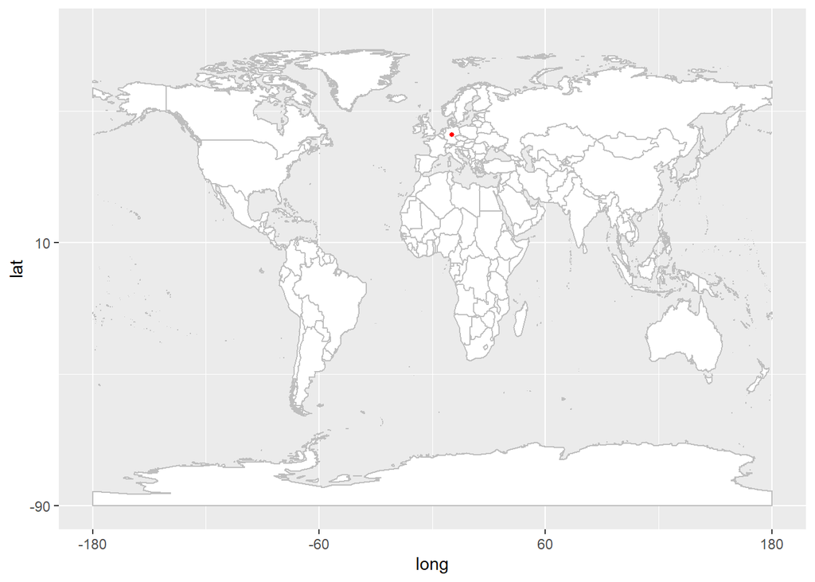

# Exploratory Data Analysis

```r
library(coronavirus)
data("coronavirus")
library(tidyverse)
library(magrittr)


germany_corona <- coronavirus %>% filter(country == "Germany")

germany_corona <- as.data.frame(germany_corona)

head(germany_corona)
```

```
        date province country      lat     long      type cases uid iso2 iso3
1 2020-01-22     <NA> Germany 51.16569 10.45153 confirmed     0 276   DE  DEU
2 2020-01-23     <NA> Germany 51.16569 10.45153 confirmed     0 276   DE  DEU
3 2020-01-24     <NA> Germany 51.16569 10.45153 confirmed     0 276   DE  DEU
4 2020-01-25     <NA> Germany 51.16569 10.45153 confirmed     0 276   DE  DEU
5 2020-01-26     <NA> Germany 51.16569 10.45153 confirmed     0 276   DE  DEU
6 2020-01-27     <NA> Germany 51.16569 10.45153 confirmed     1 276   DE  DEU
  code3 combined_key population continent_name continent_code
1   276      Germany   83783945         Europe             EU
2   276      Germany   83783945         Europe             EU
3   276      Germany   83783945         Europe             EU
4   276      Germany   83783945         Europe             EU
5   276      Germany   83783945         Europe             EU
6   276      Germany   83783945         Europe             EU
```

```r
tail(germany_corona)
```

```
           date province country      lat     long     type cases uid iso2 iso3
2647 2022-06-18     <NA> Germany 51.16569 10.45153 recovery     0 276   DE  DEU
2648 2022-06-19     <NA> Germany 51.16569 10.45153 recovery     0 276   DE  DEU
2649 2022-06-20     <NA> Germany 51.16569 10.45153 recovery     0 276   DE  DEU
2650 2022-06-21     <NA> Germany 51.16569 10.45153 recovery     0 276   DE  DEU
2651 2022-06-22     <NA> Germany 51.16569 10.45153 recovery     0 276   DE  DEU
2652 2022-06-23     <NA> Germany 51.16569 10.45153 recovery     0 276   DE  DEU
     code3 combined_key population continent_name continent_code
2647   276      Germany   83783945         Europe             EU
2648   276      Germany   83783945         Europe             EU
2649   276      Germany   83783945         Europe             EU
2650   276      Germany   83783945         Europe             EU
2651   276      Germany   83783945         Europe             EU
2652   276      Germany   83783945         Europe             EU
```

```r
summary(germany_corona)
```

```
      date              province           country               lat
 Min.   :2020-01-22   Length:2652        Length:2652        Min.   :51.17
 1st Qu.:2020-08-29   Class :character   Class :character   1st Qu.:51.17
 Median :2021-04-07   Mode  :character   Mode  :character   Median :51.17
 Mean   :2021-04-07                                         Mean   :51.17
 3rd Qu.:2021-11-14                                         3rd Qu.:51.17
 Max.   :2022-06-23                                         Max.   :51.17
      long           type               cases               uid
 Min.   :10.45   Length:2652        Min.   :-3659260   Min.   :276
 1st Qu.:10.45   Class :character   1st Qu.:      13   1st Qu.:276
 Median :10.45   Mode  :character   Median :     404   Median :276
 Mean   :10.45                      Mean   :   10491   Mean   :276
 3rd Qu.:10.45                      3rd Qu.:    6795   3rd Qu.:276
 Max.   :10.45                      Max.   :  527487   Max.   :276
     iso2               iso3               code3     combined_key
 Length:2652        Length:2652        Min.   :276   Length:2652
 Class :character   Class :character   1st Qu.:276   Class :character
 Mode  :character   Mode  :character   Median :276   Mode  :character
                                       Mean   :276
                                       3rd Qu.:276
                                       Max.   :276
   population       continent_name     continent_code
 Min.   :83783945   Length:2652        Length:2652
 1st Qu.:83783945   Class :character   Class :character
 Median :83783945   Mode  :character   Mode  :character
 Mean   :83783945
 3rd Qu.:83783945
 Max.   :83783945
```